# DS400: Assignment II (R)

Mohamed Elsherif (Student ID: 6378374)

2024-11-30

### Directory set up & Libraries Installation

```r
# Load all libraries needed
library(rstudioapi)
library(readr)
library(data.table)
```

```r
library(ggplot2)
library(lubridate)
library(tidyr)
library(dplyr)
library(scales)
library(RColorBrewer)
library(RSQLite)
options(warn = -1)
```

# Importing Data

### 1.Use relative paths to load the data.

```r
# Set working directory to the R md location
library(here)
knitr::opts_chunk$set(root.dir = here::here())
cat("Current working directory is:", getwd(), "\n")
```

```
## Current working directory is: C:/Users/Admin/Downloads/DS400_W24/Assignment02
```

### 2. Load the data athletes and medals data into your environment. Print the first 10 observations in each dataset. Also print all variable names for each dataset.

```r
# Load athletes and medals datasets
athletes <- read_csv("./data/athletes.csv")
medals <- read_csv("./data/medals.csv")
# Print first 10 rows of each dataset
cat("First 10 observations in the athletes dataset:\n")
```

```
## First 10 observations in the athletes dataset:
```

```r
head(athletes, 10)
```

```
## # A tibble: 10 × 35
##       code name        name_short name_tv gender `function` country_code country
##      <dbl> <chr>       <chr>      <chr>   <chr>  <chr>      <chr>        <chr>
##  1 1532872 ALEKSANYAN… ALEKSANYA… Artur … Male   Athlete    ARM          Armenia
##  2 1532873 AMOYAN Mal… AMOYAN M   Malkha… Male   Athlete    ARM          Armenia
##  3 1532874 GALSTYAN S… GALSTYAN S Slavik… Male   Athlete    ARM          Armenia
##  4 1532944 HARUTYUNYA… HARUTYUNY… Arsen … Male   Athlete    ARM          Armenia
##  5 1532945 TEVANYAN V… TEVANYAN V Vazgen… Male   Athlete    ARM          Armenia
##  6 1532951 ARENAS Lor… ARENAS L   Lorena… Female Athlete    COL          Colomb…
##  7 1533112 McKENZIE A… McKENZIE A Ashley… Male   Athlete    JAM          Jamaica
##  8 1533136 BASS BITTA… BASS BITT… Gina M… Female Athlete    GAM          Gambia
##  9 1533176 CAMARA Ebr… CAMARA E   Ebrahi… Male   Athlete    GAM          Gambia
## 10 1533188 RUEDA SANT… RUEDA SAN… Lizeth… Female Athlete    MEX          Mexico
## # ℹ 27 more variables: country_full <chr>, nationality <chr>,
## #   nationality_full <chr>, nationality_code <chr>, height <dbl>, weight <dbl>,
## #   disciplines <chr>, events <chr>, birth_date <date>, birth_place <chr>,
## #   birth_country <chr>, residence_place <chr>, residence_country <chr>,
## #   nickname <chr>, hobbies <chr>, occupation <chr>, education <chr>,
## #   family <chr>, lang <chr>, coach <chr>, reason <chr>, hero <chr>,
## #   influence <chr>, philosophy <chr>, sporting_relatives <chr>, …
```

```r
cat("\nFirst 10 observations in the medals dataset:\n")
```

```
##
## First 10 observations in the medals dataset:
```

```r
head(medals, 10)
```

```
## # A tibble: 10 × 11
##    medal_type   medal_code medal_date name  country_code gender discipline event
##    <chr>             <dbl> <date>     <chr> <chr>        <chr>  <chr>      <chr>
##  1 Gold Medal            1 2024-07-27 Remc… BEL          M      Cycling R… Men'…
##  2 Silver Medal          2 2024-07-27 Fili… ITA          M      Cycling R… Men'…
##  3 Bronze Medal          3 2024-07-27 Wout… BEL          M      Cycling R… Men'…
##  4 Gold Medal            1 2024-07-27 Grac… AUS          W      Cycling R… Wome…
##  5 Silver Medal          2 2024-07-27 Anna… GBR          W      Cycling R… Wome…
##  6 Bronze Medal          3 2024-07-27 Chlo… USA          W      Cycling R… Wome…
##  7 Gold Medal            1 2024-07-27 China CHN          W      Diving     Wome…
##  8 Silver Medal          2 2024-07-27 Unit… USA          W      Diving     Wome…
##  9 Bronze Medal          3 2024-07-27 Grea… GBR          W      Diving     Wome…
## 10 Gold Medal            1 2024-07-27 OH S… KOR          M      Fencing    Men'…
## # ℹ 3 more variables: event_type <chr>, url_event <chr>, code <chr>
```

```r
# Print column names for both datasets
cat("\nColumn names in the athletes dataset:\n")
```

```
##
## Column names in the athletes dataset:
```

```r
print(names(athletes))
```

```
##  [1] "code"               "name"               "name_short"
##  [4] "name_tv"            "gender"             "function"
##  [7] "country_code"       "country"            "country_full"
## [10] "nationality"        "nationality_full"   "nationality_code"
## [13] "height"             "weight"             "disciplines"
## [16] "events"             "birth_date"         "birth_place"
## [19] "birth_country"      "residence_place"    "residence_country"
## [22] "nickname"           "hobbies"            "occupation"
## [25] "education"          "family"             "lang"
## [28] "coach"              "reason"             "hero"
## [31] "influence"          "philosophy"         "sporting_relatives"
## [34] "ritual"             "other_sports"
```

```r
cat("\nColumn names in the medals dataset:\n")
```

```
##
## Column names in the medals dataset:
```

```r
print(names(medals))
```

```
##  [1] "medal_type"   "medal_code"   "medal_date"   "name"         "country_code"
##  [6] "gender"       "discipline"   "event"        "event_type"   "url_event"
## [11] "code"
```

### 3. How many different nationalities are there in the athletes dataset?

```r
# Remove NA values, then get the unique nationalities
unique_nationalities <- unique(athletes$nationality[!is.na(athletes$nationality)])

# Print number of unique nationalities
cat("Number of different nationalities in the athletes dataset:", length(unique_nationalities), "\n")
```

```
## Number of different nationalities in the athletes dataset: 197
```

# Data Visualization

### 4. Create a barplot showing the number of athletes per nationality (from highest to lowest). What is wrong with this plot?

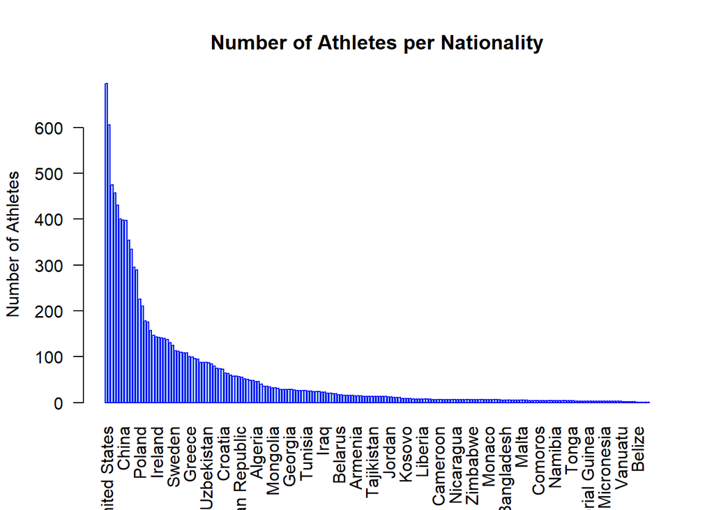

```r
# Remove NA values, then get the count of athletes per nationality stored as a table
athletes_per_nationality <- table(athletes$nationality[!is.na(athletes$nationality)])

# Sort the table from highest to lowest
athletes_per_nationality_sorted <- sort(athletes_per_nationality, decreasing = TRUE)

# plot barplot
barplot(
  athletes_per_nationality_sorted,
  main = "Number of Athletes per Nationality",
  ylab = "Number of Athletes",
  las = 2,
  col = "lightblue",
  border = "blue"
)
```

**comment** The barplot has several issues: a large number of categories can clutter the x-axis, especially if NaN or empty nationalities are not filtered out, and the dominance of a few nationalities may overshadow less-represented ones, making them nearly invisible. Additionally, displaying all categories can lead to a top-heavy visualization that lacks meaningful comparison. In R, the barplot() function is not able to fit all the labels on the x-axis by default.

### 5. Make another barplot where only the most common nationalities are displayed (defined as having at least 100 athletes at the Olympics). The remaining athletes should be grouped into a “other” bar. Include the actual number of athletes in each bar.

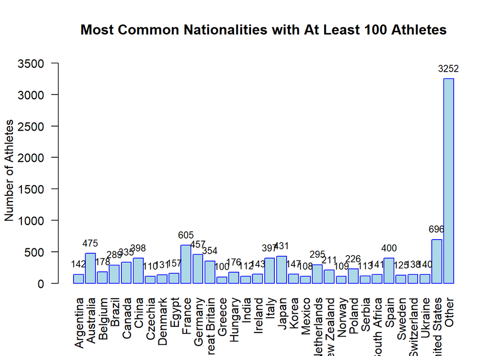

```r
# Identify nationalities with at least 100 athletes
common_nationalities <- athletes_per_nationality[athletes_per_nationality >= 100]

# Get nationalities with less than 100 athletes and group as 'Other'
other_nationalities_count <- sum(athletes_per_nationality[athletes_per_nationality < 100])

# Add 'Other' category to table
common_nationalities <- c(common_nationalities, "Other" = other_nationalities_count)

# Plot
plotMitNumb <- barplot(
  common_nationalities,
  main = "Most Common Nationalities with At Least 100 Athletes",
  ylab = "Number of Athletes",
  las = 2,
  col = "lightblue",
  border = "blue",
  names.arg = names(common_nationalities),
  ylim = c(0, max(common_nationalities) * 1.1)
)

# Add number of athletes
text(
  x = plotMitNumb,
  y = common_nationalities,
  labels = common_nationalities,
  pos = 3,
  cex = 0.8,
  col = "black"
)
```

### 6. Using the medals dataset, select the top 5 countries with the most medals. Create a plot showing the number of medals on the y-axis and the countries on the x-axis. Color the bars per gender. To make the plot easier to read, include only athletes that identify themselves as male or female. Use a colorblind-friendly palette

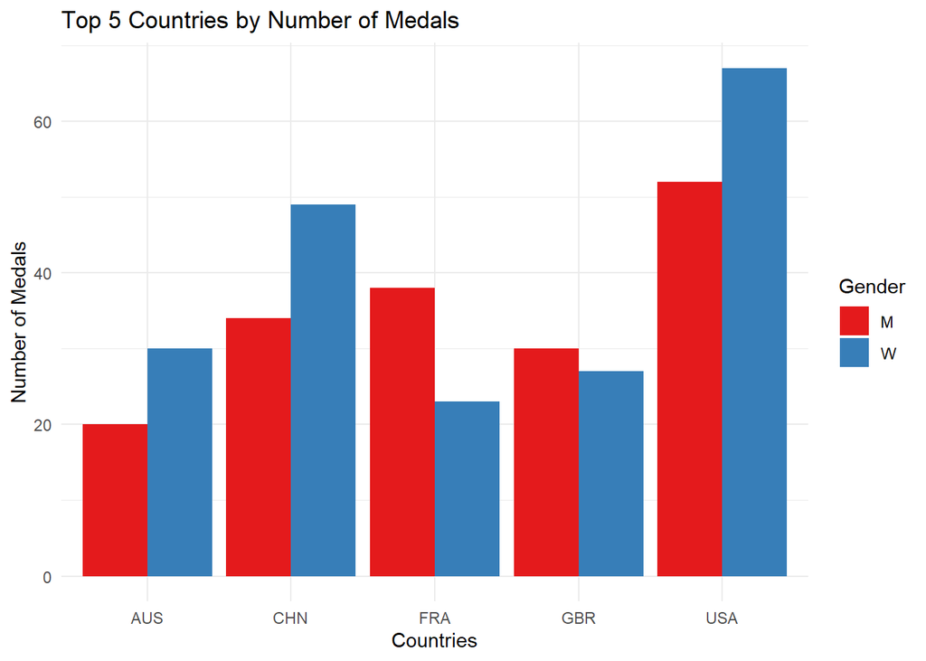

```r
# Filter medals dataset to include only male and female athletes
medals_filtered <- medals[medals$gender %in% c("M", "W"), ]

# Count total number of medals per country grouped by gender
country_medals_gender <- table(medals_filtered$country_code, medals_filtered$gender)

# Sum total medals for each country
total_medals_by_country <- rowSums(country_medals_gender)

# Sort countries by total medals in descending order then select top 5
top_countries <- names(sort(total_medals_by_country, decreasing = TRUE)[1:5])

# Subset dataset to include only top 5 countries
top_countries_data <- medals_filtered[medals_filtered$country_code %in% top_countries, ]

# Count number of medals per country and gender
top_country_medals_gender <- table(top_countries_data$country_code, top_countries_data$gender)

# convert to a data frame
top_country_medals_gender_df <- as.data.frame(top_country_medals_gender)
colnames(top_country_medals_gender_df) <- c("Country", "Gender", "Medals")

# colorblind palette
colors <- brewer.pal(3, "Set1")

# plot barplot
ggplot(top_country_medals_gender_df, aes(x = Country, y = Medals, fill = Gender)) +
  geom_bar(stat = "identity", position = "dodge") +
  scale_fill_manual(values = colors[1:2]) +
  labs(title = "Top 5 Countries by Number of Medals",
       x = "Countries",
       y = "Number of Medals",
       fill = "Gender") +
  theme_minimal()
```

### 7. Re-create the previous plot but facet by medal type. Are there any differences between the medal types?

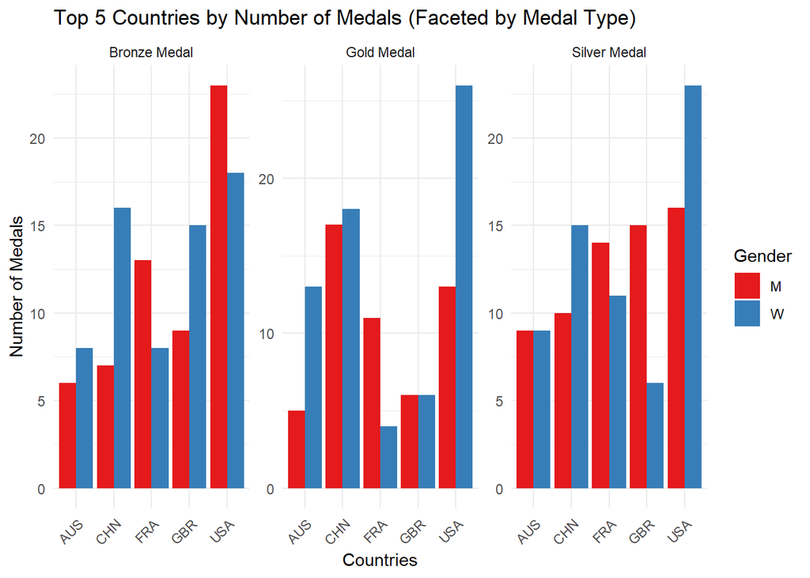

```r
# Count total number of medals per country grouped by gender + medal type
country_medals_gender_type <- table(medals_filtered$country_code, medals_filtered$gender, medals_filtered$medal_type)

# convert to a data frame
country_medals_gender_type_df <- as.data.frame(country_medals_gender_type)
colnames(country_medals_gender_type_df) <- c("Country", "Gender", "MedalType", "Medals")

# Filter to include only the top 5 countries (based on total medals)
total_medals_by_country <- rowSums(table(medals_filtered$country_code, medals_filtered$gender))
top_countries <- names(sort(total_medals_by_country, decreasing = TRUE)[1:5])

# Subset data to include only top 5 countries
top_countries_data <- country_medals_gender_type_df[country_medals_gender_type_df$Country %in% top_countries, ]

# colorblind palette
colors <- brewer.pal(3, "Set1")

# plot barplot with faceting by medal type
ggplot(top_countries_data, aes(x = Country, y = Medals, fill = Gender)) +
  geom_bar(stat = "identity", position = "dodge") +
  scale_fill_manual(values = colors[1:2]) +
  labs(title = "Top 5 Countries by Number of Medals (Faceted by Medal Type)",
       x = "Countries",
       y = "Number of Medals",
       fill = "Gender") +
  facet_wrap(~MedalType, scales = "free_y") +
  theme_minimal() +
  theme(axis.text.x = element_text(angle = 45, hjust = 1))
```

### 8. Create a plot that shows the cumulative medals won by the top 3 country over time?

```r
# collect total number of medals per country over time
medals_summary <- medals %>%
  filter(!is.na(country_code) & !is.na(medal_date)) %>%
  group_by(country_code) %>%
  summarise(total_medals = n()) %>%
  arrange(desc(total_medals))

# Select top 3 countries
top_3_countries <- head(medals_summary$country_code, 3)

# Filter for top 3 countries
medals_top_3 <- medals %>%
  filter(country_code %in% top_3_countries & !is.na(medal_date)) %>%
  mutate(medal_date = as.Date(medal_date))

# Calculate cumulative medals over time for each country
medals_cumulative <- medals_top_3 %>%
  group_by(country_code, medal_date) %>%
  summarise(daily_medals = n()) %>%
  arrange(medal_date) %>%
  mutate(cumulative_medals = cumsum(daily_medals))
```

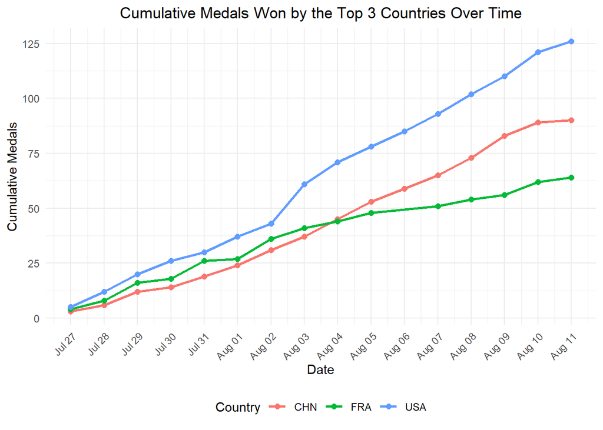

```r
ggplot(medals_cumulative, aes(x = medal_date, y = cumulative_medals, color = country_code, group = country_code)) +
  geom_line(linewidth = 1) +
  geom_point(size = 2) +
  labs(
    title = "Cumulative Medals Won by the Top 3 Countries Over Time",
    x = "Date",
    y = "Cumulative Medals",
    color = "Country"
  ) +
  scale_x_date(
    date_breaks = "1 day",
    date_labels = "%b %d"
  ) +
  theme_minimal() +
  theme(
    plot.title = element_text(hjust = 0.5),
    legend.position = "bottom",
    axis.text.x = element_text(angle = 45, hjust = 1)
  )
```

### 9. Import the athletics dataset (discipline_athletics.csv). Keep only the data from women’s and men’s 100m and 200m finals. Print the dimensions of the resulting dataset.

```r
# Import Discp. athletics dataset
discipline_athletics <- read_csv("./data/discipline_athletics.csv")
# Filter data to keep only men's and women's 100m and 200m finals
MW_100200 <- discipline_athletics[
  discipline_athletics$event_code %in% c('ATHM100M', 'ATHM200M', 'ATHW100M', 'ATHW200M') &
  discipline_athletics$stage == 'Final' &
  discipline_athletics$gender %in% c('M', 'W'),
]

# Print dimensions of Discp. athletics dataset
cat("Dimensions of the filtered dataset:", dim(MW_100200), "\n")
```

```
## Dimensions of the filtered dataset: 32 24
```

### 10. Create two plots (side-by-side) that shows the distribution of the athletes’ ages and their finish time, once for the 100m final and once for the 200m final. Color the athletes by their gender. Do not use a shared axes for the two plots. What can you observe from the plots?

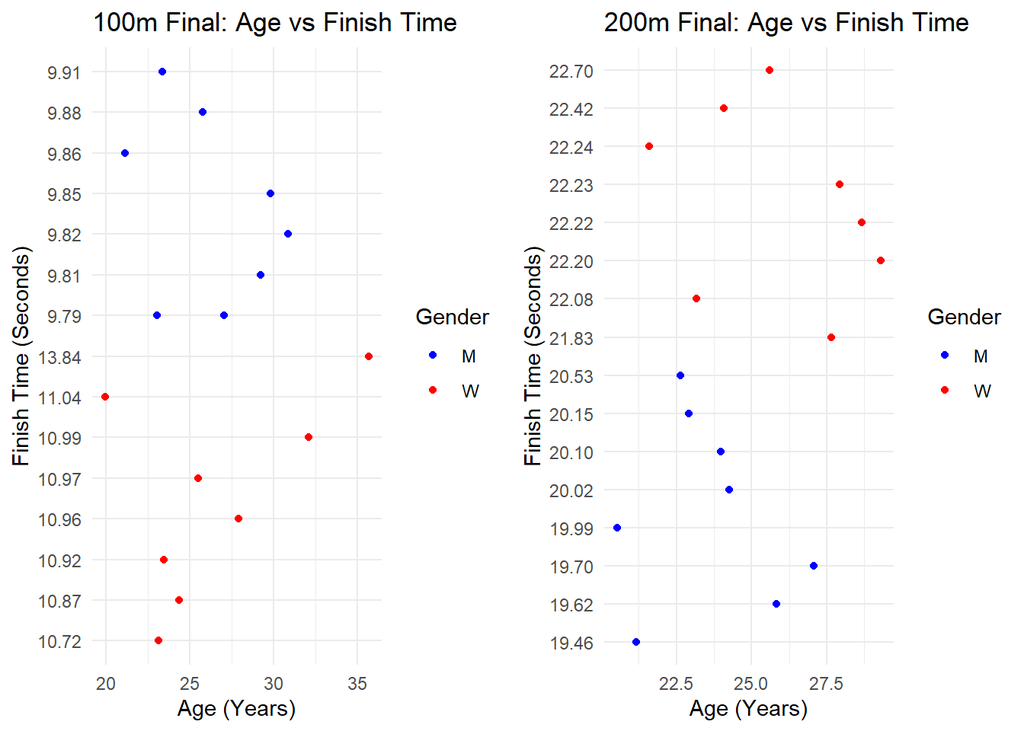

```r
# Convert date columns to Date format and calculate age
MW_100200$date <- as.Date(MW_100200$date)
athletes$birth_date <- as.Date(athletes$birth_date)

# Merge two datasets on the participant_code and code
merged_data <- merge(MW_100200, athletes, by.x = "participant_code", by.y = "code")

# Calculate age as (difference between the date and birth_date)
merged_data$age <- as.numeric(difftime(merged_data$date, merged_data$birth_date, units = "days")) / 365.25

# Split dataset for 100m and 200m
data_100m <- merged_data[grepl("ATHM100M|ATHW100M", merged_data$event_code), ]
data_200m <- merged_data[grepl("ATHM200M|ATHW200M", merged_data$event_code), ]

# plot for 100m
p1 <- ggplot(data_100m, aes(x = age, y = result, color = gender.x)) +
  geom_point() +
  labs(title = "100m Final: Age vs Finish Time",
       x = "Age (Years)",
       y = "Finish Time (Seconds)",
       color = "Gender") +  # Use labs() to set the legend title
  scale_color_manual(values = c("M" = "blue", "W" = "red")) +
  theme_minimal()

# plot for 200m
p2 <- ggplot(data_200m, aes(x = age, y = result, color = gender.x)) +
  geom_point() +
  labs(title = "200m Final: Age vs Finish Time",
       x = "Age (Years)",
       y = "Finish Time (Seconds)",
       color = "Gender") +  # Use labs() to set the legend title
  scale_color_manual(values = c("M" = "blue", "W" = "red")) +
  theme_minimal()

# put the two plots side by side
library(gridExtra)
grid.arrange(p1, p2, ncol = 2)
```

**comment** In both the 100m and 200m final races, younger athletes, particularly those in their early 20s, tend to perform the best, with male athletes consistently achieving faster times than their female counterparts. The fastest times in both races are dominated by male athletes, with female athletes generally recording slower times and showing more variability in performance. Age also plays a role, as older athletes tend to have slower finish times, especially in the female category. Overall, the 100m and 200m finals shows the advantage of youth and the gender performance disparity in sprinting events

# SQL

### 11. Print the names of all tables in the database.

```r
db_path <- "./data/imdb.db"

# Establish connection
conn <- dbConnect(SQLite(), db_path)

# list all tables in the database
query <- "SELECT name FROM sqlite_master WHERE type='table';"

# Execute query
tables <- dbGetQuery(conn, query)

cat("Tables in the IMDb database:\n")
```

```
## Tables in the IMDb database:
```

```r
print(tables)
```

```
##      name
## 1 ratings
## 2   names
## 3  titles
```

### 12. Print the first 10 rows of the names table.

```r
# select first 10 rows from the 'names' table
query <- "SELECT * FROM names LIMIT 10;"

# Execute query
names_data <- dbGetQuery(conn, query)

cat("First 10 rows of the 'names' table:\n")
```

```
## First 10 rows of the 'names' table:
```

```r
print(names_data)
```

```
##        nconst          primaryName birthYear deathYear
## 1   nm2022849           Liz Fuller        NA        NA
## 2  nm14917090 Nadine Kurkchubasche        NA        NA
## 3   nm9059617           Greg Smith        NA        NA
## 4   nm2649914          Farah Fayed        NA        NA
## 5   nm1968586          Maureen Fry        NA        NA
## 6   nm7408054         Hagar Scherf        NA        NA
## 7  nm16080814           Zack Smith        NA        NA
## 8  nm10665585          Indy Miller        NA        NA
## 9   nm4353414    Richard T. Gordon        NA        NA
## 10 nm14455950      Takuya Tanimura        NA        NA
##                    primaryProfession                          knownForTitles
## 1  manager,casting_director,producer tt2175470,tt3014478,tt5190038,tt2847592
## 2                               <NA>                                    <NA>
## 3                  camera_department                               tt6819682
## 4                             editor tt1029243,tt2526130,tt2870870,tt3461578
## 5                            actress                               tt0148583
## 6                 assistant_director                               tt4777584
## 7                               <NA>                              tt26342131
## 8                               <NA>                                    <NA>
## 9                               <NA>                                    <NA>
## 10                             actor                               tt0433499
```

### 13. How many unique names exist in the names table?

```r
# count number of unique names in 'names' table
query <- "
SELECT COUNT(DISTINCT primaryName)
FROM names
WHERE primaryName IS NOT NULL;
"
# Execute query
unique_names_count <- dbGetQuery(conn, query)

cat("Number of unique names in the 'names' table:", unique_names_count[1,1], "\n")
```

```
## Number of unique names in the 'names' table: 98487
```

### 14. What is the average rating of all titles in the ratings table?

```r
# get column information of 'ratings' table
query <- "PRAGMA table_info(ratings);"

# Execute query
ratings_columns <- dbGetQuery(conn, query)

cat("Columns in 'ratings' table:\n")
```

```
## Columns in 'ratings' table:
```

```r
print(ratings_columns)
```

```
##   cid          name    type notnull dflt_value pk
## 1   0        tconst    TEXT       0         NA  0
## 2   1 averageRating    REAL       0         NA  0
## 3   2      numVotes INTEGER       0         NA  0
```

```r
# calculate average rating from 'ratings' table
query <- "SELECT AVG(averageRating) FROM ratings;"

# Execute query
avg_rating <- dbGetQuery(conn, query)

cat("Average rating of all titles in 'ratings' table:", avg_rating[1,1], "\n")
```

```
## Average rating of all titles in 'ratings' table: 6.957862
```

### 15. What is the average rating of all titles in the ratings table that have less than 100 votes?

```r
# calculate average rating for titles with fewer than 100 votes
query <- "
  SELECT AVG(averageRating) AS avg_rating
  FROM ratings
  WHERE numVotes < 100;
"
# Execute query
result <- dbGetQuery(conn, query)

cat("The average rating for titles with less than 100 votes is:", result$avg_rating, "\n")
```

```
## The average rating for titles with less than 100 votes is: 7.008584
```

### 16. List the names, birth years, and primary professions of the 10 oldest actors/actresses in the database.

```r
# Query to get the 10 oldest actors/actresses
query <- "
  SELECT primaryName, birthYear, primaryProfession
  FROM names
  WHERE (primaryProfession LIKE '%actor%' OR primaryProfession LIKE '%actress%')
    AND birthYear IS NOT NULL
  ORDER BY birthYear ASC
  LIMIT 10;
"
# Execute query
oldest_actors <- dbGetQuery(conn, query)

cat("The 10 oldest actors/actresses:\n")
```

```
## The 10 oldest actors/actresses:
```

```r
print(oldest_actors)
```

```
##          primaryName birthYear       primaryProfession
## 1  Frederick Bernard      1848                   actor
## 2          Tom Merry      1853                   actor
## 3       Frank McNish      1853                   actor
## 4       August Kiehl      1854                   actor
## 5   Gabriela Montani      1854                 actress
## 6     Ernest Hendrie      1859            actor,writer
## 7        Edward Hoyt      1859                   actor
## 8         Peter Lang      1859                   actor
## 9         Kate Bruce      1860 actress,archive_footage
## 10 William McIllwain      1863                   actor
```

### 17. Which three movies have the lowest ratings? Print their name, release year, title type, and rating.

```r
# find the three movies with lowest ratings
query <- "
  SELECT t.primaryTitle, t.startYear, t.titleType, r.averageRating
  FROM titles t
  JOIN ratings r ON t.tconst = r.tconst
  WHERE t.titleType = 'movie'
  ORDER BY r.averageRating ASC
  LIMIT 3;
"
# Execute query
lowest_rated_movies <- dbGetQuery(conn, query)

cat("The three movies with the lowest ratings:\n")
```

```
## The three movies with the lowest ratings:
```

```r
print(lowest_rated_movies)
```

```
##              primaryTitle startYear titleType averageRating
## 1              Robot Wars      2016     movie           2.4
## 2      Silencio de muerte      1991     movie           2.8
## 3 Strippers vs Werewolves      2012     movie           3.0
```

### 18. Create a histogram plot that shows the distribution of TV series ratings vs. movie ratings. What can you observe from the plot?

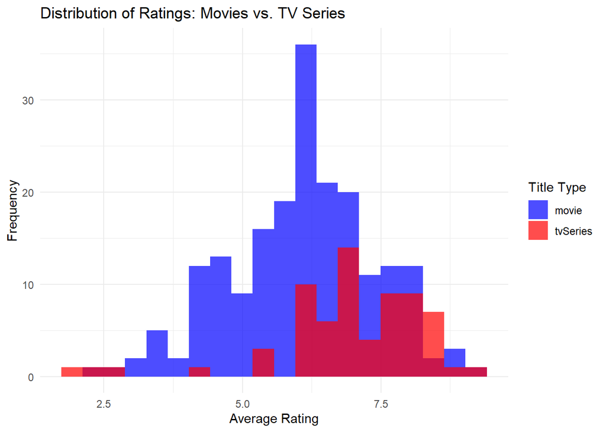

```r
# get ratings for movies and TV series
query <- "
  SELECT t.titleType, r.averageRating
  FROM titles t
  JOIN ratings r ON t.tconst = r.tconst
  WHERE t.titleType IN ('movie', 'tvSeries');
"
# Execute query
ratings_data <- dbGetQuery(conn, query)

# Convert title_type to a factor
ratings_data$titleType <- as.factor(ratings_data$titleType)

# plot histogram
ggplot(ratings_data, aes(x = averageRating, fill = titleType)) +
  geom_histogram(position = "identity", alpha = 0.7, bins = 20) +
  scale_fill_manual(values = c("movie" = "blue", "tvSeries" = "red")) +
  labs(
    title = "Distribution of Ratings: Movies vs. TV Series",
    x = "Average Rating",
    y = "Frequency",
    fill = "Title Type"
  ) +
  theme_minimal()
```

**Comment:** **TV Series**are generally rated higher than movies, with more frequent ratings above 7 and fewer very low ratings. On the other hand, **Movies** have a wider distribution of ratings, from extremely low to very high. There also seem to be extreme outliers on both ends for both movies and TV series. Some titles have ratings as low as 1.9 (TV series), and others as high as 9.2 (movies), indicating that both genres have extremes in viewer reception.

### 19. Close the connection to the database (if applicable).

```r
dbDisconnect(conn)
```

| **END OF SOLUTION** |
| --- |